# Assignment_8

Use the data that you used for week 7 assignment, use PCA to reduce the dataset’s dimensionality with an explained variance ratio of 95%.

Train a new Random Forest classifier on the reduced dataset and see how long it takes. Was training much faster?

Evaluate the classifier on the test set. How does it compare to the previous classifier that you built in Week 7 assignment?

Load the MNIST dataset

```python
from sklearn.datasets import fetch_openml
import time
```

Get the MNIST data using the below code

```python
mnist = fetch_openml('mnist_784', version=1, as_frame=False)
mnist.keys()
```

```
dict_keys(['data', 'target', 'frame', 'categories', 'feature_names', 'target_names', 'DESCR', 'details', 'url'])
```

define train and test data

```python
train, test = mnist["data"], mnist["target"]
```

Train Test data details

```python
print(train.shape)
print(test.shape)
```

```
(70000, 784)
(70000,)
```

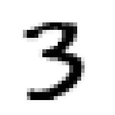

```python
%matplotlib inline
import matplotlib as mpl
import matplotlib.pyplot as plt

img = train[10000]
image_shape = img.reshape(28, 28)
plt.imshow(image_shape, cmap=mpl.cm.binary)
plt.axis("off")

plt.show()
```

```python
test[10000]
```

```
'3'
```

```python
def plot_digits(instances, images_per_row=10, **options):
    size = 28
    images_per_row = min(len(instances), images_per_row)
    n_rows = (len(instances) - 1) // images_per_row + 1
    n_empty = n_rows * images_per_row - len(instances)
    padded_instances = np.concatenate([instances, np.zeros((n_empty, size * size))], axis=0)
    image_grid = padded_instances.reshape((n_rows, images_per_row, size, size))
    big_image = image_grid.transpose(0, 2, 1, 3).reshape(n_rows * size,images_per_row * size)
    plt.imshow(big_image, cmap = mpl.cm.binary, **options)
    plt.axis("off")
```

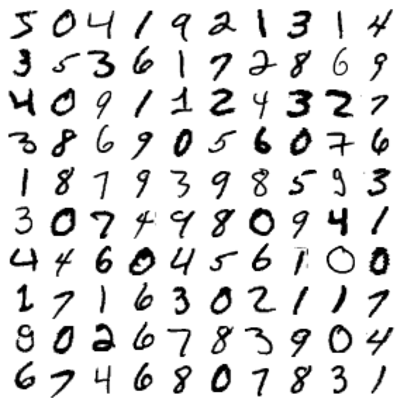

```python
import numpy as np
plt.figure(figsize=(12,12))
example_images = train[:100]
plot_digits(example_images, images_per_row=10)
plt.show()
```

split data into train(60000) and test (10000)

```python
X_train = mnist['data'][:60000]
y_train = mnist['target'][:60000]

X_test = mnist['data'][60000:]
y_test = mnist['target'][60000:]
```

Train a Random Forest classifier on the dataset and time how long it takes, then evaluate the resulting model on the test set.

```python
from sklearn.ensemble import RandomForestClassifier
```

```python
time_one_100 = time.time()
rnd_clf = RandomForestClassifier(n_estimators=100, max_leaf_nodes=16, random_state=42)
random_forest_clf=rnd_clf.fit(X_train, y_train)
time_two_100 = time.time()
```

Train a Random Forest classifier on the dataset

```python
print ( "Training time {:.2f}s ".format(time_two_100 - time_one_100))
```

```
Training time 17.88s
```

```python
from sklearn.metrics import accuracy_score
```

evaluate the resulting model on the test set.

```python
y_pred_one = rnd_clf.predict(X_test)
pred_score_100 = accuracy_score(y_test, y_pred_one)
print(pred_score_100)
```

```
0.8245
```

```python
rnd_clf = RandomForestClassifier(n_estimators=200, random_state=42)
```

```python
time_one_200 = time.time()
rnd_clf.fit(X_train, y_train)
time_two_200 = time.time()
```

```python
print("Training time {:.2f}s".format(time_two_200 - time_one_200))
```

```
Training time 128.99s
```

```python
y_pred_two = rnd_clf.predict(X_test)
pred_score_200 = accuracy_score(y_test, y_pred_two)
print(pred_score_200)
```

```
0.9707
```

```python
rnd_clf = RandomForestClassifier(n_estimators=400, random_state=42)
```

```python
time_one_400 = time.time()
rnd_clf.fit(X_train, y_train)
time_two_400 = time.time()
```

```python
print("Training time {:.2f}s".format(time_two_400 - time_one_400))
```

```
Training time 253.97s
```

```python
y_pred_three = rnd_clf.predict(X_test)
pred_score_400 = accuracy_score(y_test, y_pred_three)
print(pred_score_400)
```

```
0.9712
```

```python
rnd_clf7 = RandomForestClassifier(n_estimators=700, max_leaf_nodes=16, random_state=42,criterion='gini', max_depth=None, min_samples_split=2, min_samples_leaf=1, min_weight_fraction_leaf=0.0, max_features='auto', min_impurity_decrease=0.0, bootstrap=True, oob_score=False, n_jobs=None, verbose=0, warm_start=False, class_weight=None, ccp_alpha=0.0, max_samples=None)
```

```python
time_one_700 = time.time()
rnd_clf.fit(X_train, y_train)
time_two_700 = time.time()
```

```python
print("Training time {:.2f}s".format(time_two_700 - time_one_700))
```

```
Training time 256.29s
```

```python
y_pred_four = rnd_clf.predict(X_test)
pred_score_700 = accuracy_score(y_test, y_pred_four)
print(pred_score_700)
```

```
0.9712
```

```python
print ( "Training time for 100 n_estimator {:.2f}s ".format(time_two_100 - time_one_100))
print("Prediction Score for 100 n_estimator ", pred_score_100)
print ( "\n Training time for 200 n_estimator {:.2f}s ".format(time_two_200 - time_one_200))
print("Prediction Score for 200 n_estimator ", pred_score_200)
print ( "\n Training time for 400 n_estimator {:.2f}s ".format(time_two_400 - time_one_400))
print("Prediction Score for 400 n_estimator ", pred_score_400)
print ( "\n Training time for 700 n_estimator {:.2f}s ".format(time_two_700 - time_one_700))
print("Prediction Score for 700 n_estimator ", pred_score_700)
```

```
Training time for 100 n_estimator 17.88s
Prediction Score for 100 n_estimator  0.8245

 Training time for 200 n_estimator 128.99s
Prediction Score for 200 n_estimator  0.9707

 Training time for 400 n_estimator 253.97s
Prediction Score for 400 n_estimator  0.9712

 Training time for 700 n_estimator 256.29s
Prediction Score for 700 n_estimator  0.9712
```

```python
from sklearn.decomposition import PCA

pca = PCA(n_components=0.95)
X_train_reduced = pca.fit_transform(X_train)
```

```python
rnd_clf8 = RandomForestClassifier(n_estimators=100, random_state=42)
```

```python
pca_start_time = time.time()
rnd_clf8.fit(X_train_reduced, y_train)
pca_end_time = time.time()
```

```python
print("Training time {:.2f}s".format(pca_end_time - pca_start_time))
```

```
Training time 163.32s
```

```python
X_test_reduced = pca.transform(X_test)

y_pred_pca = rnd_clf8.predict(X_test_reduced)
pred_score_pca = accuracy_score(y_test, y_pred_pca)
print(pred_score_pca)
```

```
0.9481
```

```python
print ( "Training time for 100 n_estimator {:.2f}s ".format(time_two_100 - time_one_100))
print("Prediction Score for 100 n_estimator ", pred_score_100)
print("\n checking with PCA")
print ( "\n Training time for 100 n_estimator {:.2f}s ".format(pca_end_time - pca_start_time))
print("Prediction Score for 100 n_estimator ", pred_score_pca)
```

```
Training time for 100 n_estimator 17.88s
Prediction Score for 100 n_estimator  0.8245

 checking with PCA

 Training time for 100 n_estimator 163.32s
Prediction Score for 100 n_estimator  0.9481
```

# Here as per result i can say like traing time with 100 estimator is more.

# prediction score with test dataset is increase compare to privios.